# ML Course Project

Philong Ho

3/12/2020

# Predicting the Manner of Barbell Lift Activity

## Background

Using devices such as Jawbone Up, Nike FuelBand, and Fitbit it is now possible to collect a large amount of data about personal activity relatively inexpensively. These type of devices are part of the quantified self movement – a group of enthusiasts who take measurements about themselves regularly to improve their health, to find patterns in their behavior, or because they are tech geeks. One thing that people regularly do is quantify how much of a particular activity they do, but they rarely quantify how well they do it. In this project, your goal will be to use data from accelerometers on the belt, forearm, arm, and dumbell of 6 participants. They were asked to perform barbell lifts correctly and incorrectly in 5 different ways. More information is available from the website here: http://web.archive.org/web/20161224072740/http:/groupware.les.inf.puc-rio.br/har (see the section on the Weight Lifting Exercise Dataset).

The training data for this project are available here:

https://d396qusza40orc.cloudfront.net/predmachlearn/pml-training.csv

The test data are available here:

https://d396qusza40orc.cloudfront.net/predmachlearn/pml-testing.csv

The data for this project come from this source: http://web.archive.org/web/20161224072740/http:/groupware.les.inf.puc-rio.br/har. If you use the document you create for this class for any purpose please cite them as they have been very generous in allowing their data to be used for this kind of assignment.

# Overview

# Cleaning the Data

Let’s first take a look at the data. We’ll look at the training data since it includes our “classe” variable that we’ll be working with.

```r
library(caret)
library(rpart)
library(RColorBrewer)
library(rattle)
library(randomForest)

download.file("https://d396qusza40orc.cloudfront.net/predmachlearn/pml-training.csv", destfile = "./training.csv")
download.file("https://d396qusza40orc.cloudfront.net/predmachlearn/pml-testing.csv", destfile = "./testing.csv")

training <- read.csv("training.csv", na.strings = c("NA", "#DIV/0!", ""))
testing <- read.csv("testing.csv", na.strings = c("NA", "#DIV/0!", ""))

str(training)
```

```
## 'data.frame':    19622 obs. of  160 variables:
##  $ X                       : int  1 2 3 4 5 6 7 8 9 10 ...
##  $ user_name               : Factor w/ 6 levels "adelmo","carlitos",..: 2 2 2 2 2 2 2 2 2 2 ...
##  $ raw_timestamp_part_1    : int  1323084231 1323084231 1323084231 1323084232 1323084232 1323084232 1323084232 1323084232 1323084232 1323084232 ...
##  $ raw_timestamp_part_2    : int  788290 808298 820366 120339 196328 304277 368296 440390 484323 484434 ...
##  $ cvtd_timestamp          : Factor w/ 20 levels "02/12/2011 13:32",..: 9 9 9 9 9 9 9 9 9 9 ...
##  $ new_window              : Factor w/ 2 levels "no","yes": 1 1 1 1 1 1 1 1 1 1 ...
##  $ num_window              : int  11 11 11 12 12 12 12 12 12 12 ...
##  $ roll_belt               : num  1.41 1.41 1.42 1.48 1.48 1.45 1.42 1.42 1.43 1.45 ...
##  $ pitch_belt              : num  8.07 8.07 8.07 8.05 8.07 8.06 8.09 8.13 8.16 8.17 ...
##  $ yaw_belt                : num  -94.4 -94.4 -94.4 -94.4 -94.4 -94.4 -94.4 -94.4 -94.4 -94.4 ...
##  $ total_accel_belt        : int  3 3 3 3 3 3 3 3 3 3 ...
##  $ kurtosis_roll_belt      : num  NA NA NA NA NA NA NA NA NA NA ...
##  $ kurtosis_picth_belt     : num  NA NA NA NA NA NA NA NA NA NA ...
##  $ kurtosis_yaw_belt       : logi  NA NA NA NA NA NA ...
```

[output cut: 86 more lines]

We can see that it is a data frame of 19622 observations of 160 variables. We can see a lot of NA values and also the first 7 variables are unncessary for our analysis. Let’s get rid of as many of them as we can.

```r
training <- training[, colSums(is.na(training)) == 0]
testing <- testing[, colSums(is.na(testing)) == 0]

training <- training[, -c(1:7)]
testing <- testing[, -c(1:7)]
```

Now we have our tidy data sets. Since our testing set does not contain the classe variable, we will be unable to check the accuracy of our prediction test. Therefore, we will do cross validation on our training set and subsample our set into a subtrain and subtest set.

```r
inTrain <- createDataPartition(y = training$classe, p = 0.7, list = FALSE)
subtrain <- training[inTrain, ]
subtest <- training[-inTrain, ]
```

# Decision Tree Model

First, we’ll look at the decision tree model as it is the simplest to start with because it doesn’t perform any bagging or boosting methods. I have also included a plot of our model for better visualization.

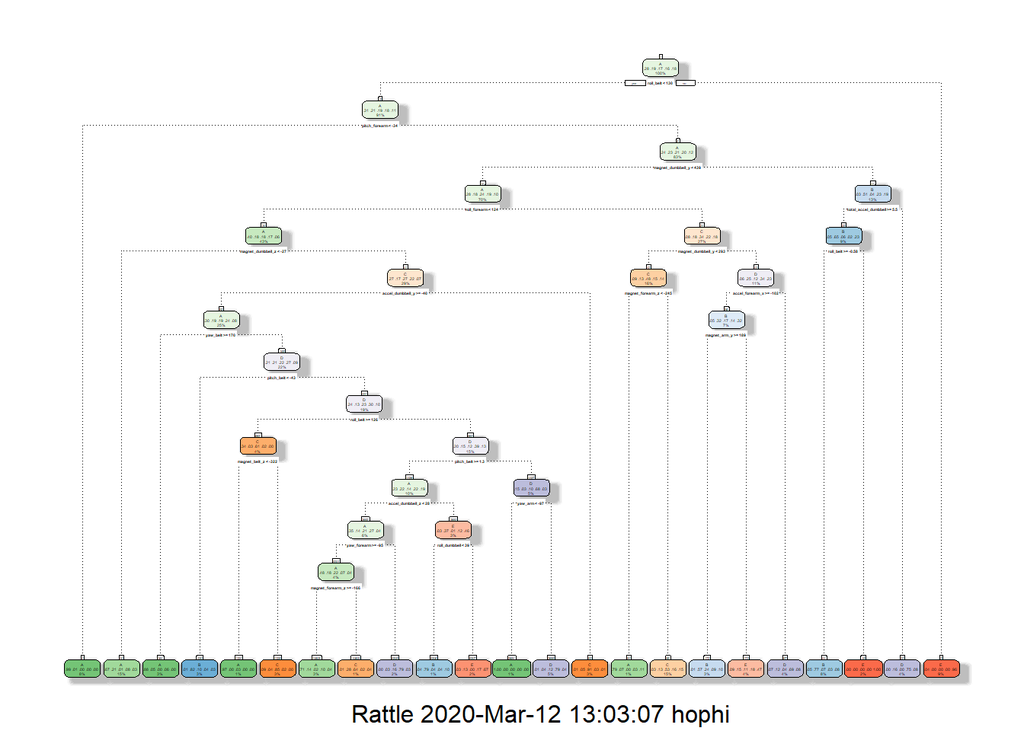

```r
set.seed(1995)
modfit.dec <- rpart(classe ~ ., method = "class", data = subtrain)
fancyRpartPlot(modfit.dec)
```

```r
pred.dec <- predict(modfit.dec, subtest, type = "class")
confusionMatrix(pred.dec, subtest$classe)
```

```
## Confusion Matrix and Statistics
##
##           Reference
## Prediction    A    B    C    D    E
##          A 1525  233   22   92   39
##          B   43  614   87   45   78
##          C   41  157  825  135  114
##          D   21   80   68  623   53
##          E   44   55   24   69  798
##
## Overall Statistics
##
##                Accuracy : 0.7451
##                  95% CI : (0.7338, 0.7562)
##     No Information Rate : 0.2845
##     P-Value [Acc > NIR] : < 2.2e-16
##
##                   Kappa : 0.6761
##
##  Mcnemar's Test P-Value : < 2.2e-16
##
## Statistics by Class:
##
##                      Class: A Class: B Class: C Class: D Class: E
## Sensitivity            0.9110   0.5391   0.8041   0.6463   0.7375
## Specificity            0.9083   0.9467   0.9080   0.9549   0.9600
## Pos Pred Value         0.7980   0.7082   0.6486   0.7373   0.8061
## Neg Pred Value         0.9625   0.8954   0.9564   0.9323   0.9420
## Prevalence             0.2845   0.1935   0.1743   0.1638   0.1839
## Detection Rate         0.2591   0.1043   0.1402   0.1059   0.1356
## Detection Prevalence   0.3247   0.1473   0.2161   0.1436   0.1682
## Balanced Accuracy      0.9097   0.7429   0.8560   0.8006   0.8488
```

Now, we’ll look at a random forest model which uses resampling to hopefully increase our accuracy.

```r
modfit.rf <- randomForest(classe ~ ., data = subtrain)
pred.rf <- predict(modfit.rf, subtest, type = "class")
confusionMatrix(pred.rf, subtest$classe)
```

```
## Confusion Matrix and Statistics
##
##           Reference
## Prediction    A    B    C    D    E
##          A 1671    3    0    0    0
##          B    3 1133    3    0    0
##          C    0    3 1021   15    0
##          D    0    0    2  949    4
##          E    0    0    0    0 1078
##
## Overall Statistics
##
##                Accuracy : 0.9944
##                  95% CI : (0.9921, 0.9961)
##     No Information Rate : 0.2845
##     P-Value [Acc > NIR] : < 2.2e-16
##
##                   Kappa : 0.9929
##
##  Mcnemar's Test P-Value : NA
##
## Statistics by Class:
##
##                      Class: A Class: B Class: C Class: D Class: E
## Sensitivity            0.9982   0.9947   0.9951   0.9844   0.9963
## Specificity            0.9993   0.9987   0.9963   0.9988   1.0000
## Pos Pred Value         0.9982   0.9947   0.9827   0.9937   1.0000
## Neg Pred Value         0.9993   0.9987   0.9990   0.9970   0.9992
## Prevalence             0.2845   0.1935   0.1743   0.1638   0.1839
## Detection Rate         0.2839   0.1925   0.1735   0.1613   0.1832
## Detection Prevalence   0.2845   0.1935   0.1766   0.1623   0.1832
## Balanced Accuracy      0.9987   0.9967   0.9957   0.9916   0.9982
```

Now we can see that our model is 99% accurate and there are very little to no values outside of the diagonals. This is by far our best model out of the two we looked at.

We will now use this model on our testing set but we will be unable to look at the accuracy of the model because the testing set does not contain our “classe” variable.

```r
pred.test <- predict(modfit.rf, newdata = testing, type = "class")
table(pred.test)
```

```
## pred.test
## A B C D E
## 7 8 1 1 3
```